# Latent Space Network Models

*Patrick O. Perry, NYU Stern School of Business*

Most of the code here is taken from examples from the [latentnet R package](https://cran.r-project.org/web/packages/latentnet/index.html) by the following authors: Pavel N. Krivitsky, Mark S. Handcock, Susan M. Shortreed, Jeremy Tantrum, Peter D. Hoff, Li Wang, and Kirk Li.

## Preliminaries

### Computing environment

We will use the following R packages.

```
library("latentnet")
```

To ensure consistent runs, we set the seed before performing any analysis.

```
set.seed(0)
```

### Data

We will analyze Sampson's monk network.

```
data(sampson)
```

```
samplike
```

```
 Network attributes:
  vertices = 18
  directed = TRUE
  hyper = FALSE
  loops = FALSE
  multiple = FALSE
  total edges= 88
    missing edges= 0
    non-missing edges= 88

 Vertex attribute names:
    cloisterville group vertex.names

 Edge attribute names:
    nominations
```

## Latent Position Models

In a latent position model, each node has an associated latent position. Notes with nearby latent positions are likely to form ties. To fit such a model, we need to specify the distance metric, and the dimension. In the example below, we use `euclidean` distance, with `d=2` dimensions.

```
(samp_fit <- ergmm(samplike ~ euclidean(d=2)))
```

```
Fitted ERGMM model:
Exponential Random Graph Mixed Model definition
Formula: samplike ~ euclidean(d = 2)
Family: Bernoulli
Terms:
- fixed effects:
 - (Intercept)
- latent space of 2 dimensions
```

For more details of the fit, use the `summary` command:

```
summary(samp_fit)
```

```
==========================
Summary of model fit
==========================

Formula:   samplike ~ euclidean(d = 2)
Attribute: edges
Model:     Bernoulli
MCMC sample of size 4000, draws are 10 iterations apart, after burnin of 10000 iterations.
Covariate coefficients posterior means:
            Estimate   2.5%  97.5% 2*min(Pr(>0),Pr(<0))
(Intercept)   2.2078 1.3769 3.1185            < 2.2e-16 ***
---
Signif. codes:  0 '***' 0.001 '**' 0.01 '*' 0.05 '.' 0.1 ' ' 1

Overall BIC:        381.9872
Likelihood BIC:     252.1252
Latent space/clustering BIC:     129.862

Covariate coefficients MKL:
            Estimate
(Intercept) 1.163472
```

We can check the MCMC convergence diagnositics:

```
mcmc.diagnostics(samp_fit)
```

```
Chain 1
Lag 0
             lpY    beta.1      Z.1.1      Z.1.2
lpY    1.0000000 0.4742584  0.1678678  0.1115915
beta.1 0.4742584 1.0000000  0.2070105  0.2009421
Z.1.1  0.1678678 0.2070105  1.0000000 -0.2905797
Z.1.2  0.1115915 0.2009421 -0.2905797  1.0000000

Lag 10
              lpY     beta.1       Z.1.1       Z.1.2
lpY    0.26575884 0.20645925  0.07526682  0.02212651
beta.1 0.21367821 0.22889886  0.08717512  0.03684092
Z.1.1  0.05245539 0.06800761  0.45962472 -0.18533520
Z.1.2  0.02585762 0.01131847 -0.18378066  0.36227548
```

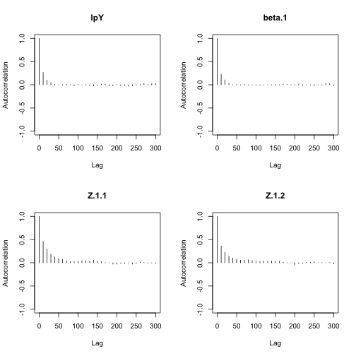

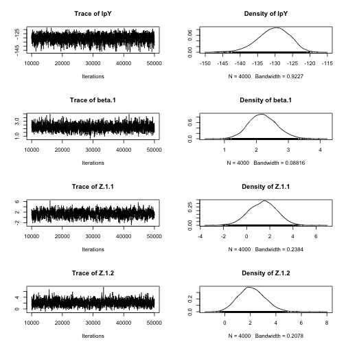

```
[[1]]

Quantile (q) = 0.025
Accuracy (r) = +/- 0.0125
Probability (s) = 0.95

        Burn-in  Total Lower bound  Dependence
        (M)      (N)   (Nmin)       factor (I)
 lpY    30       7170  600          12.0
 beta.1 40       7490  600          12.5
 Z.1.1  40       7800  600          13.0
 Z.1.2  40       7800  600          13.0
```

We can also use the estimated latent positions to plot the network.

```
plot(samp_fit)
```

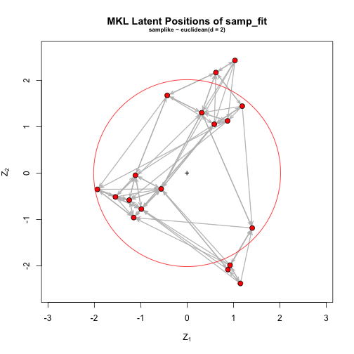

## Model-Based Clustering Models

```
(samp_fit2 <- ergmm(samplike ~ euclidean(d=2, G=3)))
```

```
Fitted ERGMM model:
Exponential Random Graph Mixed Model definition
Formula: samplike ~ euclidean(d = 2, G = 3)
Family: Bernoulli
Terms:
- fixed effects:
 - (Intercept)
- latent space of 2 dimensions in 3 clusters
```

```
summary(samp_fit2)
```

```
==========================
Summary of model fit
==========================

Formula:   samplike ~ euclidean(d = 2, G = 3)
Attribute: edges
Model:     Bernoulli
MCMC sample of size 4000, draws are 10 iterations apart, after burnin of 10000 iterations.
Covariate coefficients posterior means:
            Estimate   2.5%  97.5% 2*min(Pr(>0),Pr(<0))
(Intercept)   2.0113 1.3297 2.7751            < 2.2e-16 ***
---
Signif. codes:  0 '***' 0.001 '**' 0.01 '*' 0.05 '.' 0.1 ' ' 1

Overall BIC:        337.7598
Likelihood BIC:     253.5318
Latent space/clustering BIC:     84.22803

Covariate coefficients MKL:
            Estimate
(Intercept)  1.18777
```

Convergence diagnostics:

```
mcmc.diagnostics(samp_fit2)
```

```
Chain 1
Lag 0
              lpY      beta.1        Z.1.1       Z.1.2
lpY    1.00000000  0.33940312  0.011056095 0.097391329
beta.1 0.33940312  1.00000000 -0.032049123 0.290736714
Z.1.1  0.01105610 -0.03204912  1.000000000 0.008744742
Z.1.2  0.09739133  0.29073671  0.008744742 1.000000000

Lag 10
               lpY      beta.1        Z.1.1        Z.1.2
lpY     0.27293386  0.32232116 -0.012964365  0.085824740
beta.1  0.32304469  0.87549029 -0.016190967  0.261043183
Z.1.1  -0.02550588 -0.02546508  0.736025398 -0.005903795
Z.1.2   0.09603661  0.26353799  0.004879753  0.768123924
```

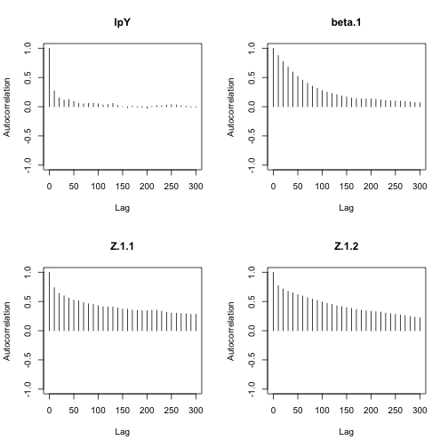

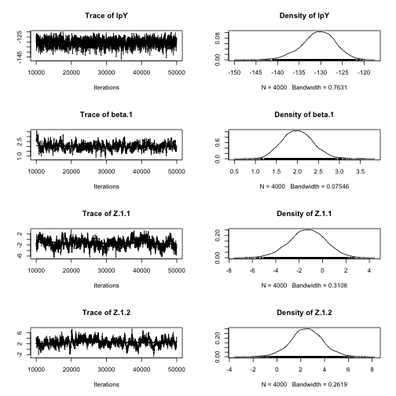

```
[[1]]

Quantile (q) = 0.025
Accuracy (r) = +/- 0.0125
Probability (s) = 0.95

        Burn-in  Total Lower bound  Dependence
        (M)      (N)   (Nmin)       factor (I)
 lpY    30       6890  600          11.5
 beta.1 130      21970 600          36.6
 Z.1.1  100      18140 600          30.2
 Z.1.2  270      52350 600          87.2
```

Fitted positions and clusters:

```
plot(samp_fit2, pie=TRUE)
```

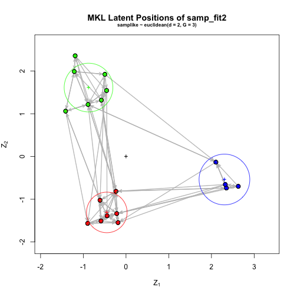

## Popularity Random Effect

We can add other terms to the model, for example a random effect capturing heterogeneous popularities of tie receivers. See the documentation for `terms.ergmm` for other possible model terms.

```
(samp_fit3 <- ergmm(samplike ~ euclidean(d=2, G=3)+rreceiver))
```

```
Fitted ERGMM model:
Exponential Random Graph Mixed Model definition
Formula: samplike ~ euclidean(d = 2, G = 3) + rreceiver
Family: Bernoulli
Terms:
- fixed effects:
 - (Intercept)
- latent space of 2 dimensions in 3 clusters
- random receiver effects
```

```
summary(samp_fit3)
```

```
==========================
Summary of model fit
==========================

Formula:   samplike ~ euclidean(d = 2, G = 3) + rreceiver
Attribute: edges
Model:     Bernoulli
MCMC sample of size 4000, draws are 10 iterations apart, after burnin of 10000 iterations.
Covariate coefficients posterior means:
            Estimate   2.5%  97.5% 2*min(Pr(>0),Pr(<0))
(Intercept)   2.0495 1.2101 2.9662            < 2.2e-16 ***
---
Signif. codes:  0 '***' 0.001 '**' 0.01 '*' 0.05 '.' 0.1 ' ' 1

Receiver effect variance: 1.001218.
Overall BIC:        335.2027
Likelihood BIC:     224.0979
Latent space/clustering BIC:     73.73878
Receiver effect BIC:     37.36593

Covariate coefficients MKL:
            Estimate
(Intercept) 1.148547
```

Convergence diagnostics:

```
mcmc.diagnostics(samp_fit3)
```

```
Chain 1
Lag 0
                   lpY      beta.1         Z.1.1       Z.1.2    receiver.1
lpY         1.00000000  0.25164623 -0.0103108221 -0.05945303 -0.2379307505
beta.1      0.25164623  1.00000000  0.0154538069 -0.18103882 -0.2498164593
Z.1.1      -0.01031082  0.01545381  1.0000000000  0.01348806  0.0009458873
Z.1.2      -0.05945303 -0.18103882  0.0134880607  1.00000000 -0.0165133365
receiver.1 -0.23793075 -0.24981646  0.0009458873 -0.01651334  1.0000000000

Lag 10
                   lpY      beta.1        Z.1.1         Z.1.2  receiver.1
lpY         0.30964946  0.16140865 -0.022500637 -0.0289526903 -0.12152890
beta.1      0.16866577  0.50908539  0.021493637 -0.0770662049 -0.21391357
Z.1.1      -0.01615094  0.03177671  0.833106110 -0.0005132335 -0.02047933
Z.1.2      -0.05070788 -0.08016389 -0.004604112  0.7749657837  0.01769491
receiver.1 -0.11176699 -0.15811914 -0.015626937  0.0009864863  0.32529743
```

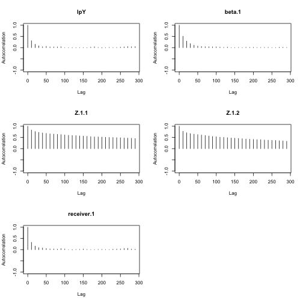

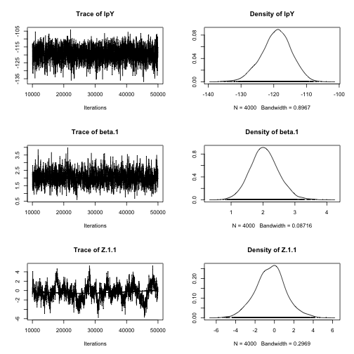

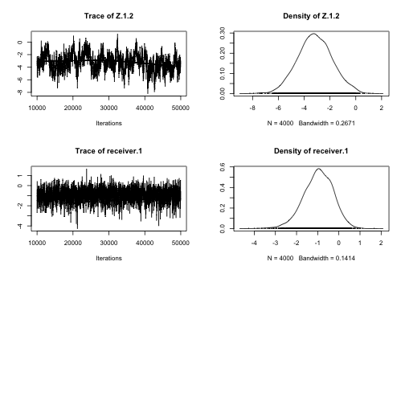

```
[[1]]

Quantile (q) = 0.025
Accuracy (r) = +/- 0.0125
Probability (s) = 0.95

            Burn-in  Total Lower bound  Dependence
            (M)      (N)   (Nmin)       factor (I)
 lpY        30       7320  600          12.2
 beta.1     50       8670  600          14.4
 Z.1.1      240      55640 600          92.7
 Z.1.2      120      27960 600          46.6
 receiver.1 40       8480  600          14.1
```

Fitted positions and clusters:

```
plot(samp_fit3, pie=TRUE)
```

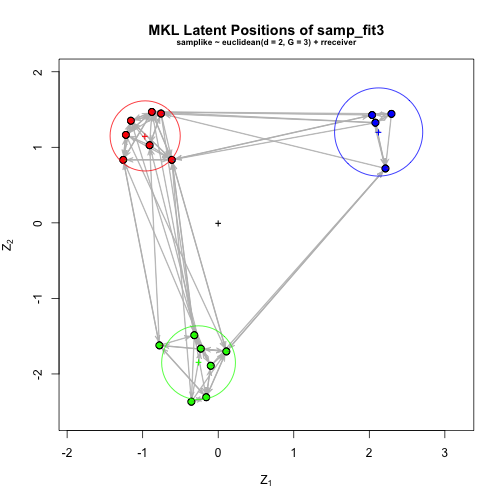

## Choosing the Number of Clusters

In the examples above, we fixed the number of clusters (`G=3`). We can choose the number of clusters automatically with BICs:

```
# Fit a set of candidate models
fits<-list(
           ergmm(samplike~euclidean(d=2,G=1)),
           ergmm(samplike~euclidean(d=2,G=2)),
           ergmm(samplike~euclidean(d=2,G=3)),
           ergmm(samplike~euclidean(d=2,G=4))
           )


# Comptue the BICs
(bics<-reshape(
    as.data.frame(t(sapply(fits,
                           function(x)c(G=x$model$G,unlist(bic.ergmm(x))[c("Y","Z","overall")])))),
    list(c("Y","Z","overall")),idvar="G",v.names="BIC",timevar="Component",
    times=c("likelihood","clustering","overall"),direction="long"
    ))
```

```
             G  Component       BIC
1.likelihood 1 likelihood 252.16378
2.likelihood 2 likelihood 253.14269
3.likelihood 3 likelihood 253.45024
4.likelihood 4 likelihood 255.00933
1.clustering 1 clustering 127.87458
2.clustering 2 clustering 120.69210
3.clustering 3 clustering  84.55446
4.clustering 4 clustering  85.53359
1.overall    1    overall 380.03835
2.overall    2    overall 373.83480
3.overall    3    overall 338.00470
4.overall    4    overall 340.54293
```

```
# Plot BIC versus number of clusters
with(bics,interaction.plot(G,Component,BIC,type="b",xlab="Clusters", ylab="BIC"))
```

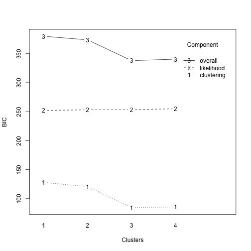

```
# Summarize and plot whichever fit has the lowest overall BIC:
bestG<-with(bics[bics$Component=="overall",],G[which.min(BIC)])
summary(fits[[bestG]])
```

```
==========================
Summary of model fit
==========================

Formula:   samplike ~ euclidean(d = 2, G = 3)
Attribute: edges
Model:     Bernoulli
MCMC sample of size 4000, draws are 10 iterations apart, after burnin of 10000 iterations.
Covariate coefficients posterior means:
            Estimate   2.5%  97.5% 2*min(Pr(>0),Pr(<0))
(Intercept)   2.0153 1.3268 2.7959            < 2.2e-16 ***
---
Signif. codes:  0 '***' 0.001 '**' 0.01 '*' 0.05 '.' 0.1 ' ' 1

Overall BIC:        338.0047
Likelihood BIC:     253.4502
Latent space/clustering BIC:     84.55446

Covariate coefficients MKL:
            Estimate
(Intercept) 1.184587
```

```
R version 3.2.3 (2015-12-10)
Platform: x86_64-apple-darwin13.4.0 (64-bit)
Running under: OS X 10.10.5 (Yosemite)

locale:
[1] en_US.UTF-8/en_US.UTF-8/en_US.UTF-8/C/en_US.UTF-8/en_US.UTF-8

attached base packages:
[1] stats     graphics  grDevices utils     datasets  base

other attached packages:
[1] latentnet_2.7.1      ergm_3.6.0           network_1.13.0       statnet.common_3.3.0
[5] knitr_1.12.3

loaded via a namespace (and not attached):
 [1] codetools_0.2-14  mvtnorm_1.0-4     lattice_0.20-33   digest_0.6.8      MASS_7.3-45
 [6] grid_3.2.3        formatR_1.1       magrittr_1.5      coda_0.18-1       evaluate_0.8
[11] stringi_1.0-1     robustbase_0.92-3 Matrix_1.2-3      sna_2.3-2         trust_0.1-7
[16] tools_3.2.3       stringr_1.0.0     DEoptimR_1.0-2    abind_1.4-3       parallel_3.2.3
[21] lpSolve_5.6.13    methods_3.2.3
```